# Merging Multiome libraries

Paula Soler-Vila

28 May 2021

# 1 Objective

The objective of this notebook is to merge multiple Multiome Seurat objects combining the scRNA data and the unified scATAC data.

# 2 Pre-processing

## 2.1 Load packages

```r
library(Signac)
library(Seurat)
library(EnsDb.Hsapiens.v86)
library(ggpubr)

set.seed(173)
```

## 2.2 Parameters

```r
# Paths
path_to_object <- here::here("multiome/results/R_objects/2.tonsil_multiome_filtered.rds")
path_to_save_object <- here::here("multiome/results/R_objects/3.tonsil_multiome_filtered_combined.rds")
```

## 2.3 Functions

```r
peaks_quantification <- function(seurat_filtered, peaks = combined.peaks){
    counts <- FeatureMatrix(
    fragments = Fragments(seurat_filtered),
    features = combined.peaks,
    cells = colnames(seurat_filtered))
    seurat_filtered[["peaks"]] <- CreateChromatinAssay(
      counts,
      genome = "hg38",
      fragments = Fragments(seurat_filtered),
      annotation = annotation)

    return(seurat_filtered)
}

default_assays <- function(seurat_object){
  DefaultAssay(seurat_object) <- "ATAC"
  return(seurat_object)
}
```

## 2.4 Load list of filtered seurat objects

```r
tonsil_data_filtered = readRDS(path_to_object)
```

### 2.4.1 Filter out the entire BCLL2 sample

Looking at the overall quality control and the analysis performed at the scRNAseq data level, we observed that this sample could lead to misinterpretation of the data. We have seen specific clusters of this sample without knowing whether it is a technical or biological variability and for this reason we decided to eliminate it from the scATAC analysis.

```r
unique(tonsil_data_filtered[[9]]$library_name)
```

```
## [1] "BCLL_2_T_1"
```

```r
unique(tonsil_data_filtered[[10]]$library_name)
```

```
## [1] "BCLL_2_T_2"
```

```r
unique(tonsil_data_filtered[[11]]$library_name)
```

```
## [1] "BCLL_2_T_3"
```

```r
tonsil_data_filtered <- tonsil_data_filtered[1:8]
```

## 2.5 Gene annotation

Extraction of gene annotations from EnsDb using hg38 as the reference assembly.

```r
annotation <- GetGRangesFromEnsDb(ensdb = EnsDb.Hsapiens.v86,standard.chromosomes = T)
seqlevelsStyle(annotation) <- "UCSC"
genome(annotation) <- "hg38"
```

## 2.6 scATAC data

### 2.6.1 Unified peaks

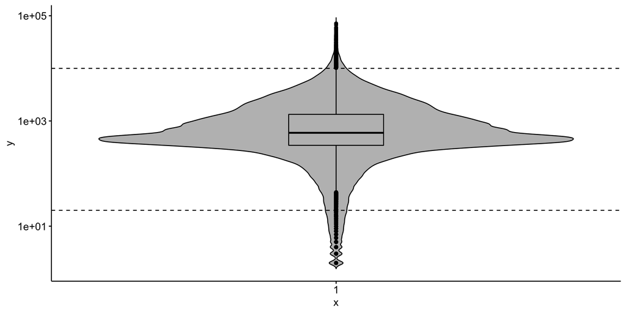

```r
# Create a unified set of peaks
tonsil_data_filtered <- lapply(tonsil_data_filtered, default_assays)
combined.peaks <- UnifyPeaks(object.list = tonsil_data_filtered, mode = "reduce")

# Keeping only standard chromosomes
combined.peaks <- keepStandardChromosomes(combined.peaks, pruning.mode = 'coarse')
peakwidths <- width(combined.peaks)

ggviolin(peakwidths,add = "boxplot",fill = "gray") + scale_y_log10() +
  geom_hline(yintercept = c(20,10000), linetype='dashed', col = 'black')
```

```r
combined.peaks <- combined.peaks[peakwidths < 10000 & peakwidths > 20]
combined.peaks
```

```
## GRanges object with 151846 ranges and 0 metadata columns:
##            seqnames            ranges strand
##               <Rle>         <IRanges>  <Rle>
##        [1]     chr1       10004-10410      *
##        [2]     chr1     180673-181713      *
##        [3]     chr1     267818-268201      *
##        [4]     chr1     586026-586378      *
##        [5]     chr1     629710-630836      *
##        ...      ...               ...    ...
##   [151842]     chrY 56829400-56837593      *
##   [151843]     chrY 56840466-56840548      *
##   [151844]     chrY 56842073-56842813      *
##   [151845]     chrY 56843869-56844010      *
##   [151846]     chrY 56850750-56850835      *
##   -------
##   seqinfo: 24 sequences from an unspecified genome; no seqlengths
```

```r
tonsil_filtered_unified_peaks <- lapply(tonsil_data_filtered, peaks_quantification)
```

# 3 Removing ATAC assay to reduce the size of the final seurat object,

```r
remove_assays <- function(seurat_object){
  DefaultAssay(seurat_object) <- "peaks"
  seurat_object@assays[["ATAC"]] <- NULL

  RenameAssays(object = seurat_object, peaks = 'ATAC')
  return(seurat_object)
}

tonsil_filtered_unified_peaks <- lapply(tonsil_filtered_unified_peaks, remove_assays)
```

## 3.1 Merging dataset

```r
object1 <- tonsil_filtered_unified_peaks[[1]]
object2 <- tonsil_filtered_unified_peaks[[2]]
object3 <- tonsil_filtered_unified_peaks[[3]]
object4 <- tonsil_filtered_unified_peaks[[4]]
object5 <- tonsil_filtered_unified_peaks[[5]]
object6 <- tonsil_filtered_unified_peaks[[6]]
object7 <- tonsil_filtered_unified_peaks[[7]]
object8 <- tonsil_filtered_unified_peaks[[8]]

merged <- merge(object1, y = list(object2, object3, object4, object5, object6,
                                  object7, object8),
add.cell.ids = c("co7dzuup_xuczw9vc","qmzb59ew_t11l8dzm","ulx1v6sz_8a2nvf1c",
                 "wdp0p728_jf6w68km","pd9avu0k_kf9ft6kk","vuuqir4h_wfkyb5v8",
                 "admae8w2_89i88tvv","sr20954q_yiuuoxng"))

## Adding gem_id column using the ids from each cell.

m = strsplit(colnames(merged), '_')
merged$gem_id <- sapply(lapply(m, '[', 1:2), paste, collapse = '_')

saveRDS(merged,path_to_save_object)
```